# AE 13: Foundations of Inference

Your Name

10.07.2021

```r
library(tidyverse)
library(knitr)
library(infer)
```

## Bulletin

- Due tomorrow:
  - lab 05
- Upcoming:
  - [project](https://sta199-f21-001.netlify.app/project/project.html) proposal (work on in lab tomorrow)
  - `hw03` released today, due next Thursday
- Misc:
  - Exam 01 grades are out (check gradescope for feedback)
  - 1 week from yesterday for regrade requests
  - make sure you make three commits per application exercise

## Midterm grade calculation

Your midterm grade is computed using the assignment grades reported on sakai but according to the weight scale described on the [syllabus](https://sta199-f21-001.netlify.app/syllabus/syllabus.pdf)

For purposes of the midterm grade, no lowest assignment scores were dropped.

```
mean ae score (as %) * 2.5
+ mean quiz score (as %) * 5
+ mean lab score (as %) * 15
+ exam 01 score (as %) * 17.5
+ hw score (as %) * 25

all divided by 65.
```

## Learning goals

- Understand how statistical inference is used to draw conclusions from sample data
- Define and understand sampling variability
- Introduce bootstrapping

## Vocabulary activity

What’s the difference between a parameter and a statistic?

Is a parameter “random” or “fixed”? Typically “Unknown” or “known”? Why?

## Bootstrapping activity: Rent in Manhattan

On a given day in 2018, twenty one-bedroom apartments were randomly selected on Craigslist Manhattan from apartments listed as “by owner”. The data are in the `manhattan` data frame. We will use this sample to conduct inference on the typical rent of 1 bedroom apartments in Manhattan.

```r
manhattan <- read_csv("data/manhattan.csv")
```

### Exercise 1

Visualize the distribution of `rent`. Is the mean or the median a better measure of typical rent of one-bedroom apartments in Manhattan?

### Exercise 2

What is a point estimate of the typical rent?

### Exercise 3

Let’s bootstrap!

- To bootstrap we will sample with replacement by drawing a value from the bowl.
- How many draws do we need for our bootstrap sample?

Fill in the values from the bootstrap sample conducted in class. Once the values are filled in, uncomment the code.

```r
# class_bootstrap <- c()
```

## Exercise 4

- About what value do you expect the bootstrap statistic to take?
- Calculate the statistic from the bootstrap sample.

```r
# add code
```

Does this statistic align with your expectations?

Here we’ve take one bootstrap sample, but in practice we will need about 10,000 - 15,000! In the next lecture we will discuss how we can calculate bootstrap samples using the `infer` package in R.

**Sneak peek!**

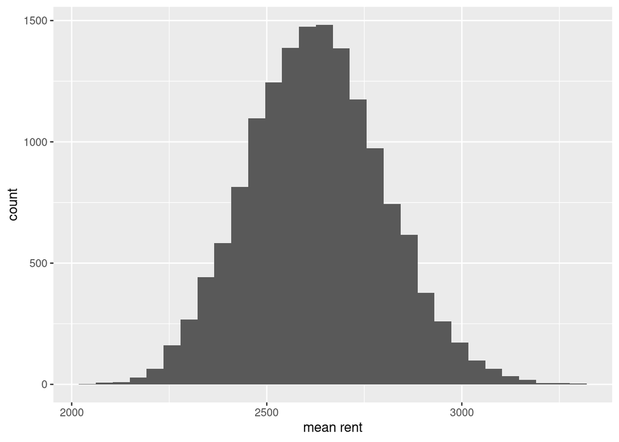

```r
boot_dist = manhattan %>%
  # specify the variable of interest
  specify(response = rent) %>%
  # generate 15000 bootstrap samples
  generate(reps = 15000, type = "bootstrap") %>%
  # calculate the statistic of each bootstrap sample
  calculate(stat = "mean")

boot_dist %>%
  ggplot(aes(x = stat)) +
  geom_histogram() +
  labs(x = "mean rent")
```